# Differential Expression Analysis of Corwing Wrasse

Carlota Myhre de Gouveia

2025-24-04

# Differential Expression Analysis with additive model

## Setup and Package Loading

```r
# Load necessary packages
suppressPackageStartupMessages({
  library(tidyverse)
  library(DESeq2)
  library(apeglm)
  library(ashr)
  library(grid)
  library(VennDiagram)
  library(readxl)
})
```

## Data Import and Preprocessing

```r
# Load transcript abundance matrix
abundance_matrix <- read.table("data/DE/abundance_matrix.txt",
                               header = TRUE, row.names = 1, check.names = FALSE)

colnames(abundance_matrix) <- sub(".*Melops", "", colnames(abundance_matrix))

sample_info <- read_excel("data/sample_conditions_rnaseq.xlsx") %>%
  mutate(
    sample = sub("L", "", RNA_Later_ID),   # matches abundance matrix columns
    origin = factor(Origin, levels = c("W","H","S")),
    temperature = factor(`Temperature (celsius)`, levels = c(12,15,18)),
    condition = factor(RNAseqgroup,
                       levels = c("W12","W15","W18",
                                  "H12","H15","H18",
                                  "S12","S15","S18")),
    length = scale(`Total length (mm)`)
  ) %>%
  select(sample, origin, temperature, condition, length)

# Reorder sample_info rows to match abundance_matrix columns
sample_info <- sample_info %>%
  arrange(match(sample, colnames(abundance_matrix)))


# Show preview of the abundance matrix
knitr::kable(abundance_matrix[1:10, 1:10], caption = "Gene abundance matrix (first 10 genes × 10 samples)")
```

Gene abundance matrix (first 10 genes × 10 samples)

|  | 1040 | 1037 | 1036 | 1035 | 1033 | 1025 | 1024 | 1023 | 1022 | 1021 |
| --- | --- | --- | --- | --- | --- | --- | --- | --- | --- | --- |
| TRINITY_GG_716_c838_g1 | 0.00 | 2.00 | 0.00 | 0.00 | 0.00 | 0.00 | 0.00 | 0.00 | 0.00 | 0.00 |
| TRINITY_GG_1114_c422_g3 | 0.00 | 0.00 | 0.00 | 0.00 | 0.00 | 0.00 | 0.00 | 0.00 | 0.00 | 0.00 |
| TRINITY_GG_1463_c526_g6 | 0.00 | 7.00 | 0.00 | 3.00 | 0.00 | 0.00 | 1.00 | 0.00 | 2.00 | 1.00 |
| TRINITY_GG_1586_c745_g1 | 0.00 | 0.00 | 0.00 | 0.00 | 0.00 | 0.00 | 0.00 | 0.00 | 0.00 | 0.00 |
| TRINITY_GG_560_c228_g1 | 1.00 | 2.00 | 1.00 | 0.00 | 0.00 | 0.00 | 0.00 | 0.00 | 0.00 | 0.00 |
| TRINITY_GG_606_c418_g2 | 1.00 | 1.00 | 1.00 | 1.00 | 3.00 | 6.00 | 5.00 | 0.00 | 2.00 | 2.00 |
| TRINITY_GG_1604_c217_g2 | 0.91 | 2.81 | 0.00 | 0.00 | 1.63 | 2.00 | 3.00 | 0.00 | 0.00 | 0.00 |
| TRINITY_GG_759_c2945_g1 | 0.00 | 0.00 | 0.00 | 0.00 | 0.00 | 0.00 | 0.00 | 0.00 | 0.00 | 0.00 |
| TRINITY_GG_1343_c279_g1 | 0.00 | 1.00 | 2.00 | 0.00 | 0.00 | 0.00 | 0.00 | 0.00 | 0.00 | 0.00 |
| TRINITY_GG_599_c87_g1 | 18.71 | 22.57 | 29.37 | 24.34 | 19.63 | 18.45 | 8.48 | 15.89 | 25.03 | 21.96 |

```r
# Show metadata
knitr::kable(sample_info, caption = "Sample metadata")
```

Sample metadata

| sample | origin | temperature | condition | length |
| --- | --- | --- | --- | --- |
| 1040 | W | 18 | W18 | -1.94352631 |
| 1037 | W | 18 | W18 | 0.24051766 |
| 1036 | W | 18 | W18 | -0.82350376 |
| 1035 | W | 18 | W18 | -0.96350658 |
| 1033 | W | 18 | W18 | 0.10051484 |
| 1025 | W | 15 | W15 | -0.34749418 |
| 1024 | W | 15 | W15 | 0.01651315 |
| 1023 | W | 15 | W15 | 0.29651879 |
| 1022 | W | 15 | W15 | -0.34749418 |
| 1021 | W | 15 | W15 | -0.45949643 |
| 1211 | W | 12 | W12 | 0.32451935 |
| 1210 | W | 12 | W12 | 1.30453909 |
| 1209 | W | 12 | W12 | -0.45949643 |
| 1206 | W | 12 | W12 | 0.66052612 |
| 1205 | W | 12 | W12 | 0.32451935 |
| 1082 | H | 18 | H18 | -1.85952462 |
| 1065 | H | 18 | H18 | -1.55151842 |
| 1061 | H | 18 | H18 | 0.24051766 |
| 1058 | H | 18 | H18 | 0.26851823 |
| 1046 | H | 18 | H18 | 1.16453627 |
| 1131 | H | 15 | H15 | 1.33253965 |
| 1075 | H | 15 | H15 | 0.68852668 |
| 1072 | H | 15 | H15 | 1.47254247 |
| 1017 | H | 15 | H15 | -0.17949079 |
| 1014 | H | 15 | H15 | -1.52351786 |
| 1202 | H | 12 | H12 | 1.50054303 |
| 1200 | H | 12 | H12 | -0.23549192 |
| 1197 | H | 12 | H12 | -0.62749981 |
| 1194 | H | 12 | H12 | -1.07550884 |
| 1192 | H | 12 | H12 | 0.40852105 |
| 1158 | S | 18 | S18 | -0.51549756 |
| 1126 | S | 18 | S18 | 0.88453063 |
| 1015 | S | 15 | S15 | 0.10051484 |
| 1010 | S | 15 | S15 | 0.10051484 |
| 1259 | S | 12 | S12 | 1.19253683 |
| 1239 | S | 12 | S12 | -1.66352067 |
| 1218 | S | 12 | S12 | 1.50054303 |
| 1195 | S | 12 | S12 | -1.13150996 |
| 1188 | S | 12 | S12 | 1.58454473 |

## Prepare dataset and run DESeq2

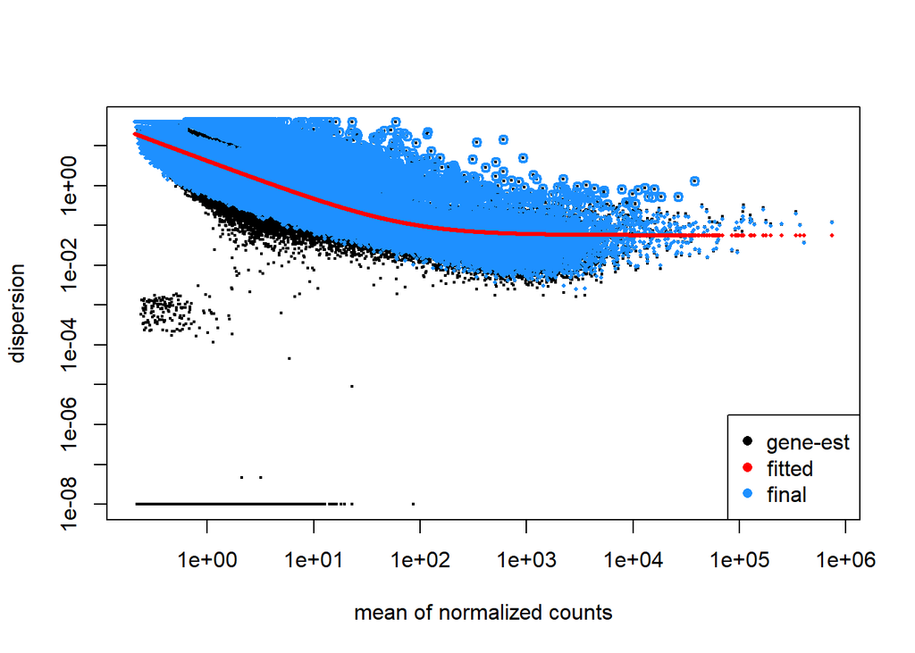

```r
# Round counts and ensure non-negative integers
abundance_matrix <- round(pmax(abundance_matrix, 0))

# Create DESeq2 dataset with additive model
dds <- DESeqDataSetFromMatrix(
  countData = abundance_matrix,
  colData   = sample_info,
  design    = ~ temperature + origin + length
)

# Filter out lowly expressed transcripts (keep those with total count ≥ 10 across all samples
dds <- dds[rowSums(counts(dds)) >= 10, ]
# Run DESeq2 pipeline (estimate size factors, dispersions, and fit model)
dds <- DESeq(dds)
# Extract coefficient names for downstream contrasts
coef_names <- resultsNames(dds)

# Plot dispersion estimates across genes to assess fit to the negative binomial model used by DESeq2
plotDispEsts(dds)
```

The close alignment of blue points with the fitted trend indicates that the DESeq2 negative binomial model adequately captures dispersion, while occasional outliers at low counts are expected and corrected by shrinkage.

## Define contrasts

```r
# Temperature contrasts (across all origins)
temperature_levels <- levels(sample_info$temperature)
temperature_contrasts <- t(combn(temperature_levels, 2))
colnames(temperature_contrasts) <- c("condition1", "condition2")
temperature_contrasts <- as.data.frame(temperature_contrasts)
temperature_contrasts
```

```
##   condition1 condition2
## 1         12         15
## 2         12         18
## 3         15         18
```

```r
# Origin contrasts (across all temperatures)
origin_levels <- levels(sample_info$origin)
origin_contrasts <- t(combn(origin_levels, 2))
colnames(origin_contrasts) <- c("condition1", "condition2")
origin_contrasts <- as.data.frame(origin_contrasts)
origin_contrasts
```

```
##   condition1 condition2
## 1          W          H
## 2          W          S
## 3          H          S
```

## Helper function to check if a contrast corresponds to a direct coefficient in the DESeq2 model.

```r
# Determines whether the comparison involves the reference level provided by DESeq2 as a coefficient. This determines whether we can use 'coef' (apeglm) or need to use 'contrast' (normal).
is_direct_coef <- function(factor_name, level1, level2, coef_names) {
  ref <- levels(sample_info[[factor_name]])[1]
  if (level2 == ref) {
    coef_pattern <- paste0(factor_name, "_", level1, "_vs_", ref)
    return(coef_pattern %in% coef_names)
  } else if (level1 == ref) {
    coef_pattern <- paste0(factor_name, "_", level2, "_vs_", ref)
    return(coef_pattern %in% coef_names)
  }
  return(FALSE)
}
```

## Main function to run pairwise differential expression analysis for a given factor (e.g., temperature or origin).

```r
# Automatically selects shrinkage method based on whether the comparison involves the reference level. Saves full and significant results, generates MA plots, and returns a summary table
run_contrast_analysis <- function(contrast_table, factor_name, output_dir, alpha = 0.05, lfcThreshold = 0.0, coef_names) {
  results_list <- list()
  counts_summary <- data.frame(
    Comparison = character(),
    Shrinkage = character(),
    Upregulated = integer(),
    Downregulated = integer(),
    stringsAsFactors = FALSE
  )
  # Create output directory if it doesn't exist
  dir.create(here::here(output_dir), recursive = TRUE, showWarnings = FALSE)

  for (i in 1:nrow(contrast_table)) {
    level1 <- contrast_table$condition1[i]
    level2 <- contrast_table$condition2[i]
    name <- paste(level2, "vs", level1, sep = "_")


    # Check if the comparison involves the reference level provided by DESeq2 as a coefficient
    # Use 'coef' with apeglm shrinkage for reference-level comparisons; use 'contrast' with normal shrinkage     otherwise
    direct_coef <- is_direct_coef(factor_name, level1, level2, coef_names)

    if (direct_coef) {
      coef_name <- paste0(factor_name, "_", level2, "_vs_", levels(sample_info[[factor_name]])[1])
      res <- lfcShrink(dds, coef = coef_name, type = "apeglm")
      shrinkage <- "apeglm"
    } else {
      res <- lfcShrink(dds, contrast = c(factor_name, level2, level1), type = "normal")
      shrinkage <- "normal"
    }

    results_list[[name]] <- res

    # Extract significant genes based on adjusted p-value and log2 fold change threshold
    sig <- res[which(res$padj < alpha & abs(res$log2FoldChange) > lfcThreshold), ]
    up <- sum(sig$log2FoldChange > 0)
    down <- sum(sig$log2FoldChange < 0)

    # Save full and significant results to CSV
    write.csv(as.data.frame(res), file = here::here(output_dir, paste0(name, "_DE_results.csv")), row.names = TRUE)
    write.csv(as.data.frame(sig), file = here::here(output_dir, paste0(name, "_significant_genes.csv")), row.names = TRUE)

    # Generate and save MA plot with up/downregulated gene counts
    png(filename = here::here(output_dir, paste0(name, "_MA_plot.png")), width = 800, height = 600)
    plotMA(res, ylim = c(-10, 10), main = paste("MA Plot:", name, "-", shrinkage), alpha = alpha, colSig = "red")
    text(x = max(res$baseMean, na.rm = TRUE) * 0.7, y = 9, labels = paste("↑:", up), col = "blue", cex = 0.8)
    text(x = max(res$baseMean, na.rm = TRUE) * 0.7, y = -9, labels = paste("↓:", down), col = "blue", cex = 0.8)
    dev.off()

    # Also display MA plot inline in the report
    plotMA(res, ylim = c(-10, 10), main = paste("MA Plot:", name, "-", shrinkage), alpha = alpha, colSig = "red")
    text(x = max(res$baseMean, na.rm = TRUE) * 0.7, y = 9, labels = paste("↑:", up), col = "blue", cex = 0.8)
    text(x = max(res$baseMean, na.rm = TRUE) * 0.7, y = -9, labels = paste("↓:", down), col = "blue", cex = 0.8)

    # Add summary row to the results table
    counts_summary <- rbind(counts_summary, data.frame(
      Comparison = name,
      Shrinkage = shrinkage,
      Upregulated = up,
      Downregulated = down
    ))
  }
  # Return list of DESeq2 results and summary tab
  return(list(results = results_list, summary = counts_summary))
}
```

## Temperature contrast

```r
# Temperature contrasts
temperature_results <- run_contrast_analysis(
  contrast_table = temperature_contrasts,
  factor_name = "temperature",
  output_dir = "results/DE/temperature_contrast_additive_model",
  coef_names = coef_names
)
```

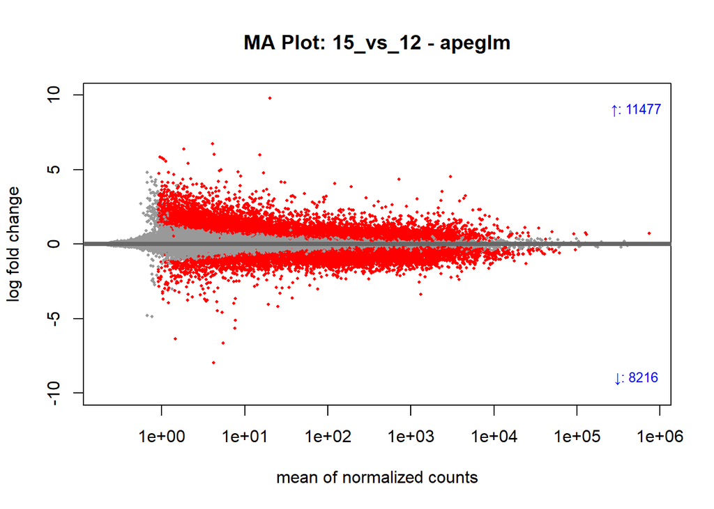

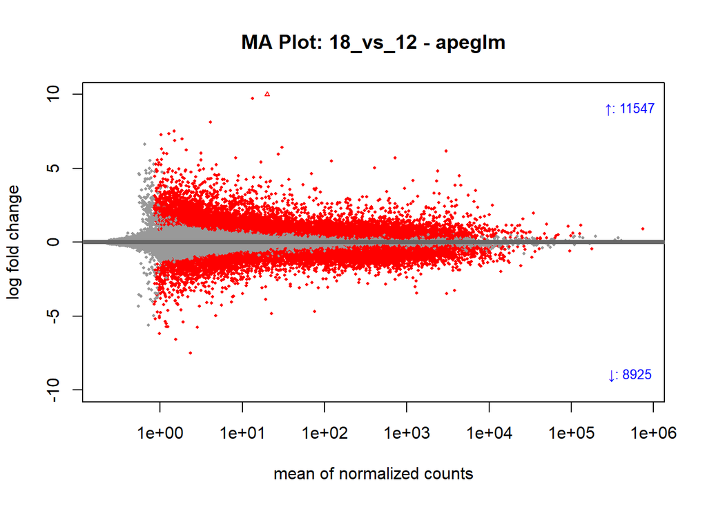

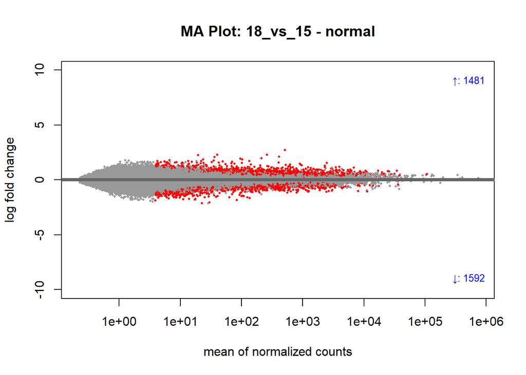

```r
print(temperature_results$summary)
```

```
##   Comparison Shrinkage Upregulated Downregulated
## 1   15_vs_12    apeglm       11477          8216
## 2   18_vs_12    apeglm       11547          8925
## 3   18_vs_15    normal        1481          1592
```

```r
## Save summary table
write.csv(
  temperature_results$summary,
  "results/DE/temperature_contrast_additive_model/contrast_summary.csv",
  row.names = FALSE
)
```

More genes were differentially expressed between 12°C and 15°C than between 15°C and 18°C, suggesting that transcriptional responsiveness is strongest at the lower end of the temperature treatments.

## Origin contrast

```r
# Origin contrast
origin_results <- run_contrast_analysis(
  contrast_table = origin_contrasts,
  factor_name = "origin",
  output_dir = "results/DE/origin_contrast_additive_model",
  coef_names = coef_names
)
```

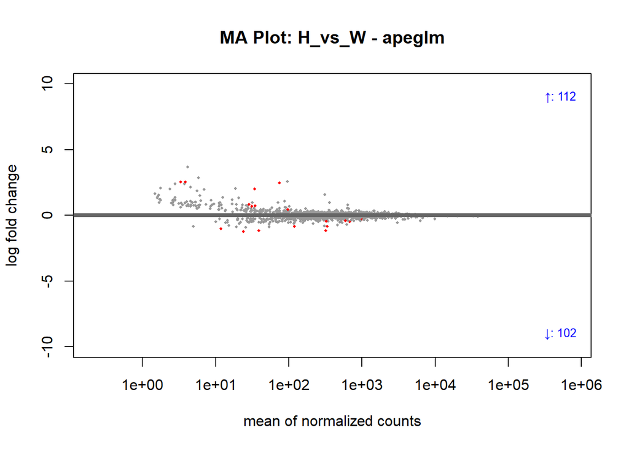

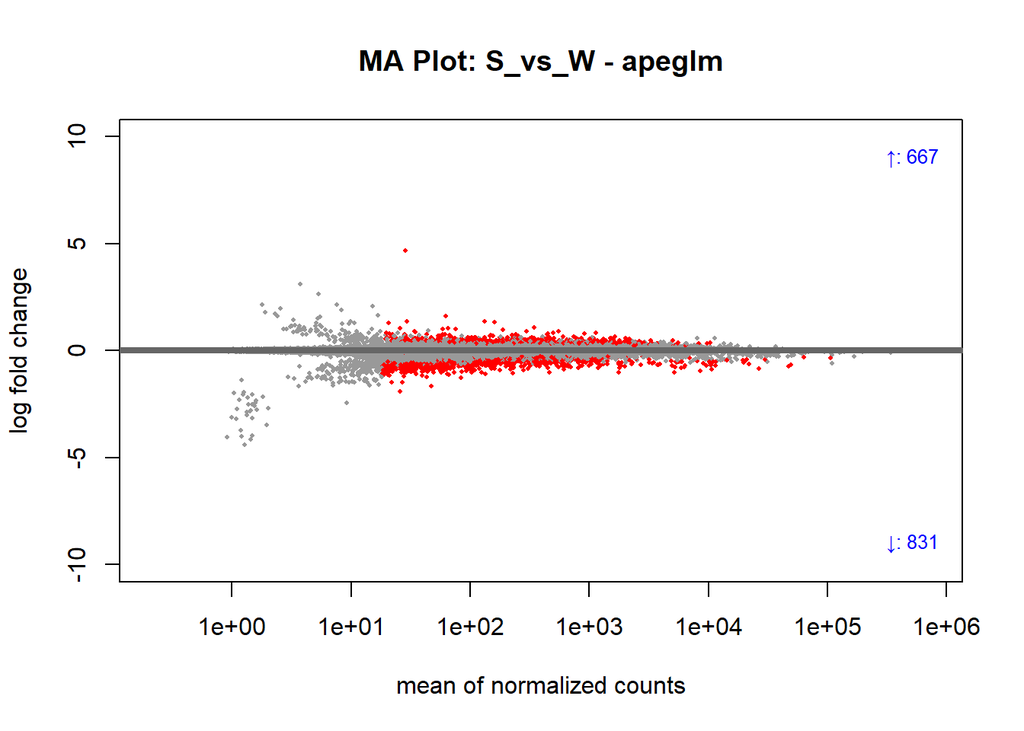

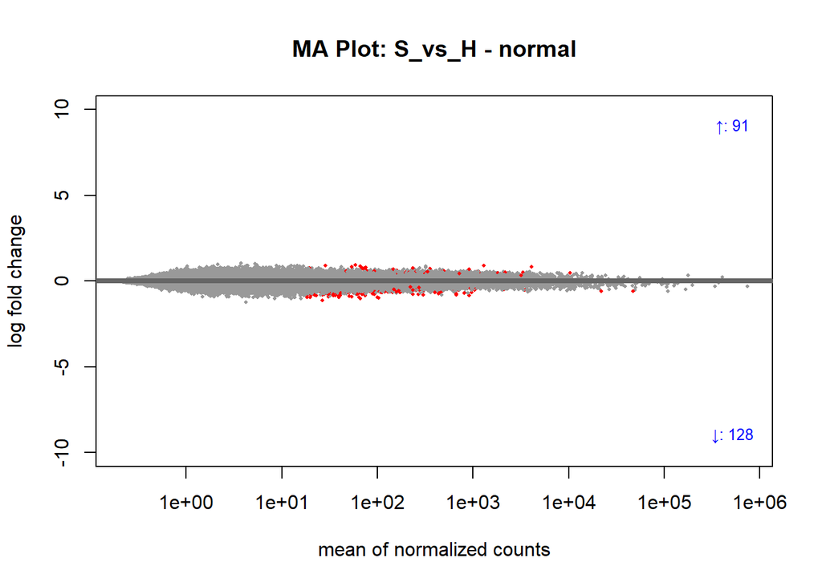

```r
print(origin_results$summary)
```

```
##   Comparison Shrinkage Upregulated Downregulated
## 1     H_vs_W    apeglm         112           102
## 2     S_vs_W    apeglm         667           831
## 3     S_vs_H    normal          91           128
```

```r
## Save summary table
write.csv(
  origin_results$summary,
  "results/DE/origin_contrast_additive_model/contrast_summary.csv",
  row.names = FALSE
)
```

The West vs South comparison yielded 1,498 DE genes, highlighting strong transcriptional divergence between parental populations. In contrast, hybrid comparisons revealed far fewer DE genes (214 vs West, 219 vs South), showing that hybrids resemble both parental populations overall, though they also exhibit distinct differences in a subset of genes.

# Venn diagrams

## Define venn plotting function

```r
# Plot Venn diagram to visualize overlap between sets of significant genes
plot_venn <- function(genes_lists, contrast_name, output_dir) {
  venn_plot <- venn.diagram(
    x = genes_lists,
    category.names = names(genes_lists),
    filename = NULL,
    fill = c("red", "green", "blue"),
    alpha = 0.5,
    cex = 2,
    fontface = "bold"
  )

  png(filename = file.path(output_dir, paste0("venn_", contrast_name, ".png")), width = 800, height = 800)
  grid.newpage()
  grid.draw(venn_plot)
  dev.off()

  grid.newpage()
  grid.draw(venn_plot)
}
```

## Prepare DE gene sets and plot venn diagrams for temperature contrast

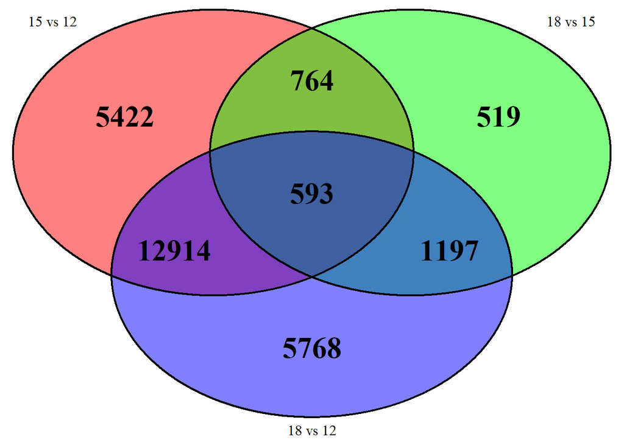

```r
# Prepare DE sets for temperature contrasts
temp_contrasts <- c("15_vs_12", "18_vs_15", "18_vs_12")
temp_sets <- setNames(lapply(temp_contrasts, function(name) {
  file <- file.path("results/DE/temperature_contrast_additive_model", paste0(name, "_significant_genes.csv"))
  rownames(read.csv(file, row.names = 1))
}), c("15 vs 12", "18 vs 15", "18 vs 12"))

# Plot Venn diagram
plot_venn(temp_sets, "temperature_contrasts", "results/DE/temperature_contrast_additive_model")
```

## Prepare DE transcripts sets and plot venn diagrams for origin contrast

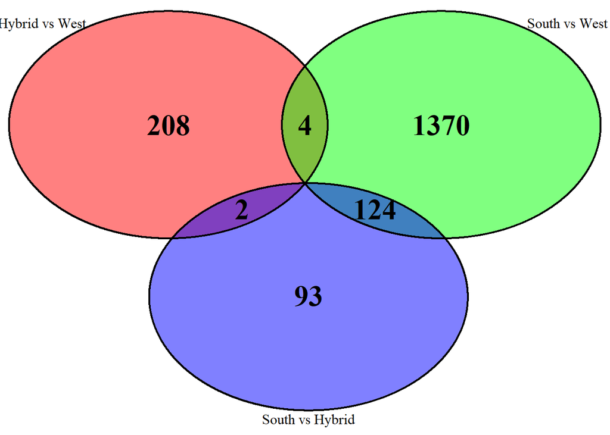

```r
origin_contrasts <- c("H_vs_W", "S_vs_W", "S_vs_H")
origin_labels    <- c("Hybrid vs West", "South vs West", "South vs Hybrid")

origin_sets <- setNames(lapply(seq_along(origin_contrasts), function(i) {
  file <- file.path("results/DE/origin_contrast_additive_model",
                    paste0(origin_contrasts[i], "_significant_genes.csv"))
  rownames(read.csv(file, row.names = 1))
}), origin_labels)

# Plot Venn diagram
plot_venn(origin_sets, "origin_contrasts", "results/DE/origin_contrast_additive_model")
```

## Function to load genes sets

```r
# Load significant gene sets used to visualize shared and unique DE genes across conditions
load_gene_sets <- function(contrast_names, contrast_dir) {
  sets <- list()
  for (name in contrast_names) {
    file <- file.path("results/DE", contrast_dir, paste0(name, "_significant_genes.csv"))
    df <- read.csv(file, row.names = 1)
    sets[[name]] <- rownames(df)
  }
  return(sets)
}
```

## Function to summarize Venn regions

```r
# Summarize the number of genes in each Venn region (shared or unique across contrasts)
venn_summary_table <- function(sets) {
  all_genes <- unique(unlist(sets))
  summary <- sapply(all_genes, function(gene) {
    present_in <- names(sets)[sapply(sets, function(s) gene %in% s)]
    paste(sort(present_in), collapse = " & ")
  })
  as.data.frame(table(summary), stringsAsFactors = FALSE) |>
    setNames(c("Region", "Count")) |>
    dplyr::arrange(desc(Count))
}
```

## Temperature Venn summary

```r
temp_contrasts <- c("15_vs_12", "18_vs_15", "18_vs_12")
temp_sets <- load_gene_sets(temp_contrasts, "temperature_contrast_additive_model")
temp_venn_summary <- venn_summary_table(temp_sets)
print(temp_venn_summary)
```

```
##                           Region Count
## 1            15_vs_12 & 18_vs_12 12914
## 2                       18_vs_12  5768
## 3                       15_vs_12  5422
## 4            18_vs_12 & 18_vs_15  1197
## 5            15_vs_12 & 18_vs_15   764
## 6 15_vs_12 & 18_vs_12 & 18_vs_15   593
## 7                       18_vs_15   519
```

```r
# Save venn summary
write.csv(
  temp_venn_summary,
  "results/DE/temperature_contrast_additive_model/venn_summary.csv",
  row.names = FALSE
)
```

## Origin Venn summary

```r
origin_contrasts <- c("H_vs_W", "S_vs_W", "S_vs_H")
origin_sets <- load_gene_sets(origin_contrasts, "origin_contrast_additive_model")
origin_venn_summary <- venn_summary_table(origin_sets)
print(origin_venn_summary)
```

```
##            Region Count
## 1          S_vs_W  1370
## 2          H_vs_W   208
## 3 S_vs_H & S_vs_W   124
## 4          S_vs_H    93
## 5 H_vs_W & S_vs_W     4
## 6 H_vs_W & S_vs_H     2
```

```r
# Save venn summary
write.csv(
  origin_venn_summary,
  "results/DE/origin_contrast_additive_model/venn_summary.csv",
  row.names = FALSE
)
```

# Gene Extraction for functional enrichment

## Tier 1: Shared temperature-responsive genes across origins. Candidates for general temperature response.

### Biological Rationale

Tier 1 identifies genes that are consistently regulated by temperature across all origins. By intersecting results from all pairwise temperature contrasts, this approach isolates genes involved in a general thermal response, independent of population-specific effects.

```r
# Extract genes that are consistently DE across all temperature contrasts
tier1_genes <- Reduce(intersect, temp_sets)

# Save for functional enrichment
write.csv(
  data.frame(gene_id = tier1_genes),
  "results/functional_enrichment/tier1_shared_temperature_response/tier1_shared_temperature_genes.csv",
  row.names = FALSE
)
```

## Tier 2: Constitutive divergence (West vs South)

### Biological Rationale

Tier 2 identifies genes that show baseline expression differences between West and South origins while controlling for temperature. These represent population‑level divergence patterns that are consistent across temperatures and may reflect fixed genetic divergence.

```r
# Load constitutive origin differences (South vs West)
pop_divergence_file <- "results/DE/origin_contrast_additive_model/S_vs_W_significant_genes.csv"
tier2_genes <- rownames(read.csv(pop_divergence_file, row.names = 1))

# Save for functional enrichment
write.csv(
  data.frame(gene_id = tier2_genes),
  "results/functional_enrichment/tier2_pop_divergence/tier2_pop_divergence_genes.csv",
  row.names = FALSE
)
```

## Tier 2b: Local thermal adaptation candidates (divergence + plasticity overlap)

### Biological Rationale

Tier 2b aims to identify genes that may be involved in thermal local adaptation between the south and the west populations. These candidates are defined by the overlap between constitutive differences from tier 2 and genes that showed significantly improved fit when including the interaction term.

- **Constitutive differences** are identified using the additive model (`~ origin + temperature + length`) by comparing origins (West vs South) while controlling for temperature. These represent **baseline expression differences** that are consistent across temperatures and may reflect fixed genetic divergence.
- **Interaction effects** are identified using a likelihood ratio test (LRT) comparing models with and without the `origin:temperature` interaction term. These transcripts show **origin-specific responses to temperature**, indicating **plasticity divergence**.

By intersecting these two sets, we isolate transcripts that are: - **Diverged between origins**, and - **Differentially responsive to temperature depending on origin** This overlap represents the strongest candidates for thermal local adaptation, as they combine constitutive divergence with temperature‑responsive regulation.

```r
# Use Tier 2 genes
constitutive_genes <- tier2_genes

# Load interaction effect genes from LRT
interaction_file <- "results/DE/interaction_effects/significant_interaction_genes.csv"
interaction_genes <- rownames(read.csv(interaction_file, row.names = 1))

# Overlap = strongest candidates for local thermal adaptation
tier2b_genes <- intersect(constitutive_genes, interaction_genes)

# Save for functional enrichment (nested under Tier 2 folder)
write.csv(
  data.frame(gene_id = tier2b_genes),
  "results/functional_enrichment/tier2_pop_divergence/tier2b_local_adaptation/tier2b_local_adaptation_candidates.csv",
  row.names = FALSE
)
```

**Tier 3: Hybrid Inheritance** In contrast to the other tiers, Tier 3 was analyzed separately using the condition model applied to an isoform‑level abundance matrix rather than a gene‑level matrix. Each origin–temperature combination was treated as a distinct group, allowing us to identify transcripts differentially expressed in hybrids relative to parental lines. This separate analysis highlights how parental expression programs are inherited, maintained, or disrupted in hybrids.

## Summary of Gene Extraction

```r
# Summarize the number of genes extracted for each tier
data.frame(
  Tier = c("Tier 1", "Tier 2", "Tier 2b"),
  Genes = c(
    length(tier1_genes),
    length(tier2_genes),
    length(tier2b_genes)
  )
)
```

```
##      Tier Genes
## 1  Tier 1   593
## 2  Tier 2  1498
## 3 Tier 2b    45
```

# Summary

This script performs Tier 1 and Tier 2 differential expression analyses using an additive DESeq2 model to investigate temperature responses and local adaptation in *Symphodus melops*. Pairwise temperature contrasts revealed 593 genes consistently regulated by temperature across all origins (Tier 1). For Tier 2, constitutive origin differences were defined using West vs. South origin fish, representing baseline population divergence. The overlap of these divergence genes with genes showing origin‑dependent temperature responses yielded 45 strong candidates for thermal local adaptation (Tier 2b). These gene sets were extracted and saved for downstream functional enrichment.